# Market Share Target Setting Methodology - Calculation and Plotting

A comprehensive explanation of the PACTA market share target setting methodology, and the associated difficulties when it comes to interpretation and plotting.

Jackson Hoffart https://github.com/jdhoffa  
2022-05-02

A core component of the PACTA methodology is the ability to allocate macro-economic efforts to micro-economic actors. More specifically, PACTA takes climate change mitigation scenarios, which provide production pathways for various sectors and technologies, and allocates these efforts to individual companies, and/or financial portfolios.

In this note, we will:

- Discuss PACTA’s current target-setting methodology (Technology- and Sector-Market Share)
- Explain the rationale and short-comings of the current volume trajectory plots
- Propose a new plotting method that aims to address these short-comings.

This note assumes a basic understanding of the PACTA methodology.

# Target-Setting with PACTA

We will use fake data throughout this note to illustrate examples.

First, let’s define a couple of fake climate scenarios. We will need to have an example of an increasing scenario, such as renewable energy production (hereby referred to as “renewables” or “renewablescap”), and a decreasing scenario, such as gas-fired energy production (hereby referred to as “gas” or “gascap”).

These scenarios will start at arbitrary values, and have varying degrees of ambition.

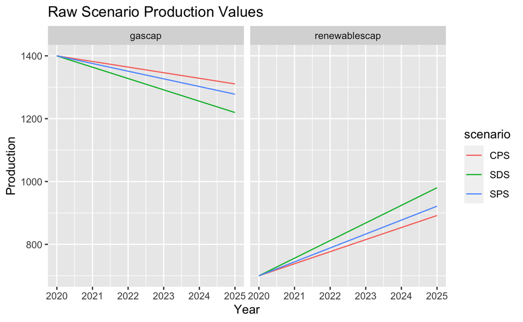

A crucial function of the PACTA methodology is to allocate a portion of the scenario production to different companies, and financial portfolios.

To do so, PACTA applies two different methods, depending on if the technology is projected to increase (as is the case with low-carbon technologies, such as renewables) or if it is projected to decrease (as is the case with high-carbon technologies, such as gas).

## High-Carbon Technologies - Technology Market Share

It is straight-forward to calculate the percent-change of any technology’s production at time $t$, as a percentage of the initial value at $t_0$:

$$\left(\frac{s_i(t)-s_i(t_0)}{s_i(t_0)}\right)*100$$

where $s(t)$ is the scenario’s production, for some technology, at time $t$.

Note that this reduces to:

$$\left(\frac{s_i(t)}{s_i(t_0)} -
1\right)*100$$

For reason’s that will become clear later, we will refer to this as the **technology-market share**.

We can transform the scenarios defined above, and plot this value:

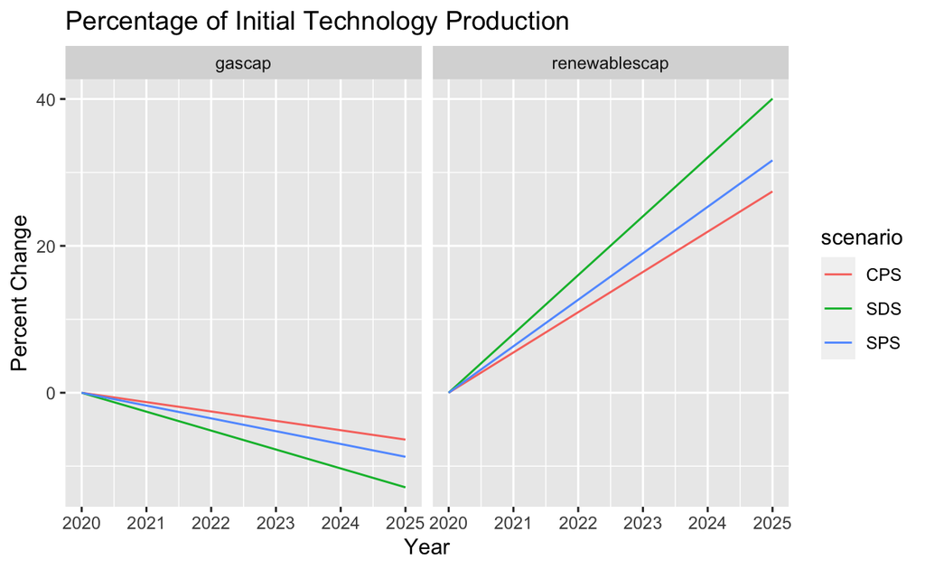

From this value, we can set a target for a portfolio as:

$$p_i^{target}(t) = p_i(t_0) +
p_i(t_0)*\left(\frac{s_i(t)-s_i(t_0)}{s_i(t_0)}\right)$$

where $p_i(t)$ is the portfolio’s actual production in technology $i$ and $p_i^{target}$ is the portfolio’s calculated target production.

## Low-Carbon Technologies - Sector Market Share

Rather than calculating the percent change as a percentage of the initial technology value, we might also calculate

$$\left(\frac{s(t) -
s(t_0)}{S(t_0)}\right)*100$$
where $S(t)$ now refers to the scenario’s production in the entire sector, at time $t$. We will refer to this as the **sector-market share**.

Plotting this value yields:

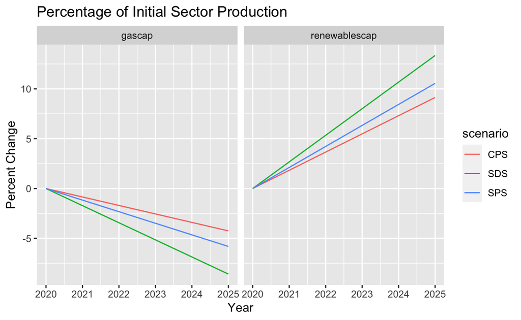

Similarly, we can use this value to calculate a target as:

$$p_i^{target}(t) = p_i(t_0) +
P(t_0)*\left(\frac{s(t) - s(t_0)}{S(t_0)}\right)$$
where $P(t_0)$ is the portfolio’s production in the entire sector.

# Rationale for Having Two Approaches

This begs the question, why two approaches? We will illustrate with an example.

## Technology-Market Share Doesn’t Work for Low-Carbon

First, imagine a portfolio that is exposed only to a high-carbon technology, such as Gas-fired Power. Lets say that $p_{gas}(t_0) = 500MW$ and $p_{renewables}(t_0) = 0MW$.

Imagine we used only the technology-market share to calculate targets. The function looks like:

$$\begin{aligned}
p_i^{target}(t) &= p_i(t_0) +
p_i(t_0)*\left(\frac{s_i(t)-s_i(t_0)}{s_i(t_0)}\right) \\
&= p_i(t_0) + p_i(t_0)*\left(\frac{s_i(t)}{s_i(t_0)} - 1\right) \\
&= p_i(t_0) * \left(\frac{s_i(t)}{s_i(t_0)}\right) \\
\end{aligned}$$

for our gas example, this would become:
$$p_{gas}^{target}(t) = 500MW *
\left(\frac{s_i(t)}{s_i(t_0)}\right)$$
just the initial gas production, multiplied by the scenario ratio. So long as there are non-zero scenario values, there will be a target for gas production.

However, for renewable power, since $p_i(t_0) = 0MW$:

$$\begin{aligned}
p_{renewables}^{target}(t) &= 0MW *
\left(\frac{s_i(t)}{s_i(t_0)}\right) \\
&= 0MW
\end{aligned}$$
Since we are multiplying by 0, we will never have a target for renewables.

This can be interpreted as follows. The portfolio is only exposed to gas, which is a technology expected to decline in production to curb climate change. Since the portfolio currently has *NO* market share in renewables, it won’t be expected to build-out renewables (following the technology-market share approach). Thus, a target calculated in this method would suggest that a portfolio simply declines it’s production entirely, without transitioning to low-carbon technologies. This doesn’t make sense, since eventually the companies would decline production so much that they fail.

Now, if we were to use instead the sector market share for renewables, we see:

$$\begin{aligned}
p_{renewables}^{target}(t) &= p_{renewables}(t_0) +
P(t_0)*\left(\frac{s(t) - s(t_0)}{S(t_0)}\right) \\
&= 0MW + 500MW * \left(\frac{s(t) - s(t_0)}{S(t_0)}\right)
\end{aligned}$$

Though the portfolio doesn’t have any exposure to the renewables *technology*, it does have exposure to the power *sector*. Thus, if we allocate the desired renewable growth scenario as a percentage of the overall *sector*, we will end up with a non-zero target.

## Sector-Market Share Doesn’t Work for High-Carbon

The natural question is then, why can’t we just apply the sector-market share equation to high-carbon technologies?

Let’s explore with another example. For now, we will just use the equations. In particular, let’s explore conditions such that the target calculated is negative (note: this should not happen, as it has no physical interpretation). If we start with the Sector-Market Share equation:

$$p_i^{target}(t) = p_i(t_0) +
P(t_0)*\left(\frac{s(t) - s(t_0)}{S(t_0)}\right)$$
For our negative target boundary-case, this becomes:

$$0 > p_i(t_0) +
P(t_0)*\left(\frac{s_i(t) - s_i(t_0)}{S(t_0)}\right)$$

Putting all portfolio-related terms on the LHS, and scenario-related terms on the RHS, and handling signs a bit, we get:

$$\frac{p_i(t_0)}{P(t_0)} <
\frac{s_i(t_0)-s_i(t)}{S(t_0)}$$

It is quite easy to satisfy this condition. Consider the fake scenario we defined above:

**Scenario Production Values**

| scenario | technology | Year | Production |
| --- | --- | --- | --- |
| SDS | gascap | 2020 | 1400.0000 |
| SDS | renewablescap | 2020 | 700.0000 |
| SDS | gascap | 2025 | 1219.6053 |
| SDS | renewablescap | 2025 | 980.3345 |

$$\begin{aligned}
p_{gas}^{target}(t) &= p_{gas}(t_0) + P(t_0)*\left(\frac{s_{gas}(t)
- s_{gas}(t_0)}{S(t_0)}\right) \\
&= 10MW + 1100MW*\left(\frac{1220MW - 1400MW}{2100MW}\right) \\
&\approx -84.3 MW
\end{aligned}$$

Specific values were chosen to illustrate the point, but as shown, this condition can be easily met with arbitrary input values. This is a problem for multiple reasons. First, of all, negative production targets have no physical interpretation. Second, since there is no physical way to produce “negative” energy, we are effectively allocating impossible scenario ambitions. Therefor, if we were to continue forward setting targets like this, we would not be adequately accounting for the necessary production ramp-down that the scenario projects.

Even if we were to just set negative targets to 0, there would be scenario ambition that does not get considered, and our targets would not adequately limit CO2 emissions to the proposed carbon budget.

# Plotting Results: Volume Trajectory Charts

Now that we have explained the target-setting methodology in detail, we can look into what the output of a PACTA run might look like for some arbitrary loanbook. For the sake of simplicity, we will assume a loanbook with only one exposure to some company that has both Gas and Renewables assets.

**Sample PACTA Output**

| Sector | Technology | Year | Region | Scenario Source | Metric | Production | Technology Share | scope | percentage_of_initial_production_by_scope |
| --- | --- | --- | --- | --- | --- | --- | --- | --- | --- |
| power | gascap | 2020 | global | demo_2020 | projected | 23178.46 | 0.5164751 | technology | 0.00000000 |
| power | gascap | 2020 | global | demo_2020 | target_CPS | 23178.46 | 0.5164751 | technology | 0.00000000 |
| power | gascap | 2020 | global | demo_2020 | target_SDS | 23178.46 | 0.5164751 | technology | 0.00000000 |
| power | gascap | 2020 | global | demo_2020 | target_SPS | 23178.46 | 0.5164751 | technology | 0.00000000 |
| power | gascap | 2025 | global | demo_2020 | projected | 24752.64 | 0.5996650 | technology | 0.06791575 |
| power | gascap | 2025 | global | demo_2020 | target_CPS | 21699.01 | 0.4568243 | technology | -0.06382884 |
| power | gascap | 2025 | global | demo_2020 | target_SDS | 20191.84 | 0.4216959 | technology | -0.12885334 |
| power | gascap | 2025 | global | demo_2020 | target_SPS | 21156.77 | 0.4445496 | technology | -0.08722284 |
| power | renewablescap | 2020 | global | demo_2020 | projected | 21699.72 | 0.4835249 | sector | 0.00000000 |
| power | renewablescap | 2020 | global | demo_2020 | target_CPS | 21699.72 | 0.4835249 | sector | 0.00000000 |
| power | renewablescap | 2020 | global | demo_2020 | target_SDS | 21699.72 | 0.4835249 | sector | 0.00000000 |
| power | renewablescap | 2020 | global | demo_2020 | target_SPS | 21699.72 | 0.4835249 | sector | 0.00000000 |
| power | renewablescap | 2025 | global | demo_2020 | projected | 16524.81 | 0.4003350 | sector | -0.11531011 |
| power | renewablescap | 2025 | global | demo_2020 | target_CPS | 25800.68 | 0.5431757 | sector | 0.09137978 |
| power | renewablescap | 2025 | global | demo_2020 | target_SDS | 27690.62 | 0.5783041 | sector | 0.13349261 |
| power | renewablescap | 2025 | global | demo_2020 | target_SPS | 26434.70 | 0.5554504 | sector | 0.10550757 |
| power | gascap | 2020 | global | demo_2020 | corporate_economy | 1195546.70 | 0.1130896 | technology | 0.00000000 |
| power | gascap | 2025 | global | demo_2020 | corporate_economy | 1218539.70 | 0.1141743 | technology | 0.01923221 |
| power | renewablescap | 2020 | global | demo_2020 | corporate_economy | 1598339.46 | 0.1511907 | sector | 0.00000000 |
| power | renewablescap | 2025 | global | demo_2020 | corporate_economy | 1483450.28 | 0.1389958 | sector | -0.01086764 |

First, let’s just plot the absolute production values:

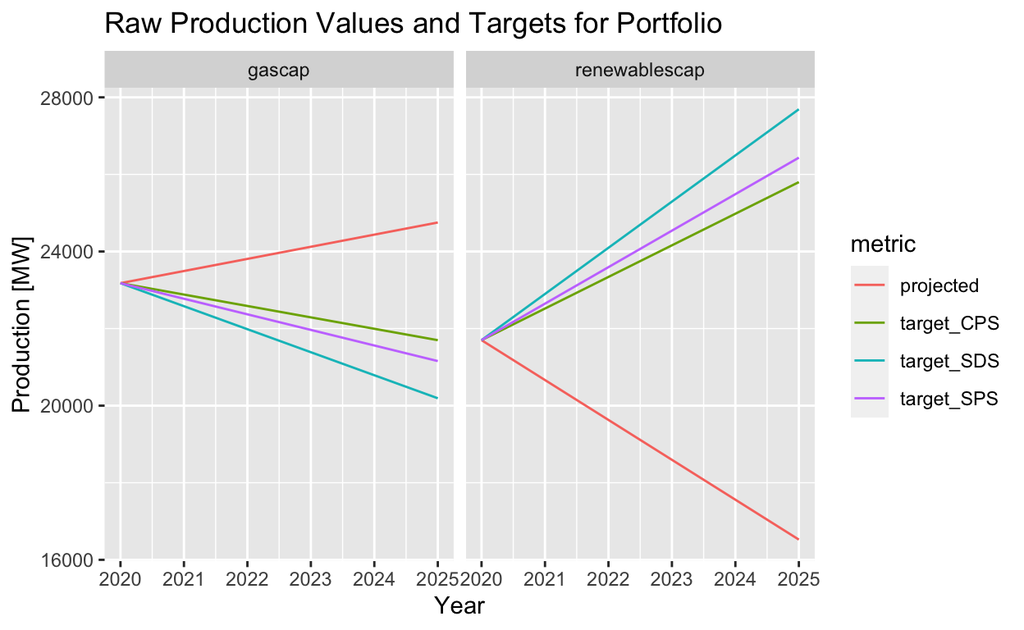

## Volume Trajectory with Technology-Market Share

Now, let’s see what we actually plot in the PACTA volume trajectory plots, using `r2dii.plot`, first for a decreasing technology (Gas).

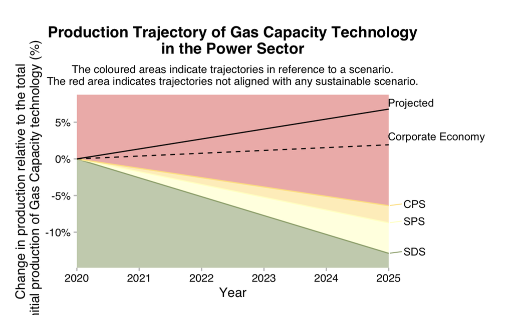

In the above plots, we are simply dividing each production value (portfolio, targets and corporate economy) by their initial value at 2020. Consider first the SDS gas Capacity trend. The actual values are:

**Absolute Change in Gas Production (SDS Target)**

| Year | Production |
| --- | --- |
| 2020 | 23178.46 |
| 2025 | 20191.84 |

which, normalized, becomes:

**Normalized Change in Gas Production (SDS Target)**

| Year | Normalized Production |
| --- | --- |
| 2020 | 1.0000000 |
| 2025 | 0.8711467 |

compare this to the tmsr values of the original scenario:

**TMSR Gas Production (SDS)**

| Year | TMSR |
| --- | --- |
| 2020 | 1.0000000 |
| 2025 | 0.8711467 |

The values are exactly the same. This is expected. For brown technologies, we apply the technology market share, which means we directly apply the percent growth that the scenario prescribes for the technology.

## Volume Trajectory with Sector-Market Share

Now, let’s see what the case is for an increasing technology:

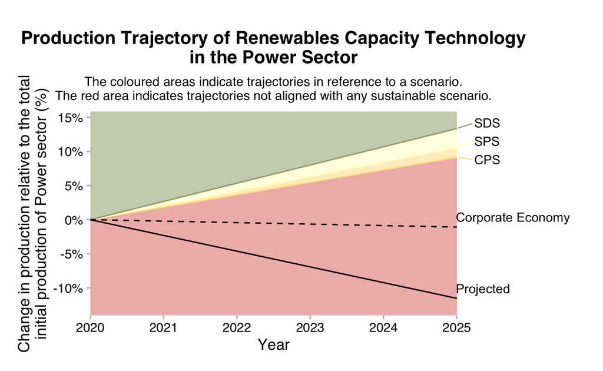

Looking at the raw target production values (for the SDS scenario), we see:

**Absolute Change in Renewables Production (SDS Target)**

| Year | Production |
| --- | --- |
| 2020 | 21699.72 |
| 2025 | 27690.62 |

which, normalized, becomes:

**Normalized Change in Renewables Production (SDS Target)**

| Year | Normalized Production |
| --- | --- |
| 2020 | 1.000000 |
| 2025 | 1.276082 |

compare this to the original scenario:

**TMSR Renewables Production (SDS)**

| Year | TMSR |
| --- | --- |
| 2020 | 1.000000 |
| 2025 | 1.400478 |

Note here that the percentage change indicated by the trajectory chart is different from that of the scenario. That is because we are showing the percentage increase as a percentage of the **sector**, not **technology**.

One way we can show this is by calculating the portfolio’s initial sector exposure:

```
[1] 44878.18
```

and determine what the growth is as a percentage of this value:

**Growth in Renewables as Percentage of Sector (SDS Target)**

| Year | Growth as Percentage of Sector |
| --- | --- |
| 2020 | 0.0000000 |
| 2025 | 0.1334926 |

comparing this to the SMSP of the original scenario, we get what we expect:

**SMSP Renewables Production (SDS)**

| Year | SMSP |
| --- | --- |
| 2020 | 0.0000000 |
| 2025 | 0.1334926 |

This is just one difficult in interpretation with the current method of plotting. On-top of this, there are actually other more precise problems.

## Problem 1: Benchmarks for Increasing Technologies

Plotting values as we currently do in `r2dii.plot``, we see a potential issue arise in the context of benchmarks. Looking at the equations, what we currently plot (for increasing technologies) is:

Actual portfolio production:

$\frac{p_i(t)}{p_i(t_0)}$

Benchmark:

$\frac{p_i^{benchmark}(t)}{p_i^{benchmark}(t_0)}$

Portfolio targets:
$$\begin{aligned}
\frac{p_i^{target}(t)}{p_i^{target}(t_0)} &=
\frac{p_i(t_0)}{p_i^{target}(t_0)} +
\frac{P(t_0)}{p_i^{target}(t_0)}*\left(\frac{s_i(t)-s_i(t_0)}{S(t_0)}\right)
\\
&= 1 +
\frac{P(t_0)}{p_i(t_0)}*\left(\frac{s_i(t)-s_i(t_0)}{S(t_0)}\right)
\end{aligned}$$
but since $p_i^{target}(t_0) = p_i(t_0)$ by definition:

$$\begin{aligned}
\frac{p_i^{target}(t)}{p_i(t_0)} &= 1 +
\frac{P(t_0)}{p_i(t_0)}*\left(\frac{s_i(t)-s_i(t_0)}{S(t_0)}\right) \\
\end{aligned}$$

The problem here is the $P(t_0)$ dependency on the RHS of the target calculations. In particular, let’s consider two different cases. In both cases, the benchmark production, and scenario values are constant. Further, the portfolio production for some increasing technology, say *renewables*, is also constant. The only differing value is the **overall** production that the portfolio has in the power sector. The proposition is that, in this situation, the benchmark would be plotted in different shaded regions defined by the scenario.

Let’s see this with actual data. Let’s define some fake Asset-Based Company Data, and two fake portfolios:

**Asset-Based Company Data**

| Company | Sector | Technology | Year | Production |
| --- | --- | --- | --- | --- |
| company 1 | power | renewablescap | 2020 | 100 |
| company 1 | power | renewablescap | 2025 | 200 |
| company 2 | power | renewablescap | 2020 | 100 |
| company 2 | power | renewablescap | 2025 | 50 |
| company 2 | power | hydrocap | 2020 | 10000 |
| company 2 | power | hydrocap | 2025 | 10000 |

**Fake Portfolio 1**

| Loan Size | Company | Sector |
| --- | --- | --- |
| 1 | company 1 | power |

**Fake Portfolio 2**

| Loan Size | Company | Sector |
| --- | --- | --- |
| 1 | company 2 | power |

Now, let’s calculate targets for these portfolios:

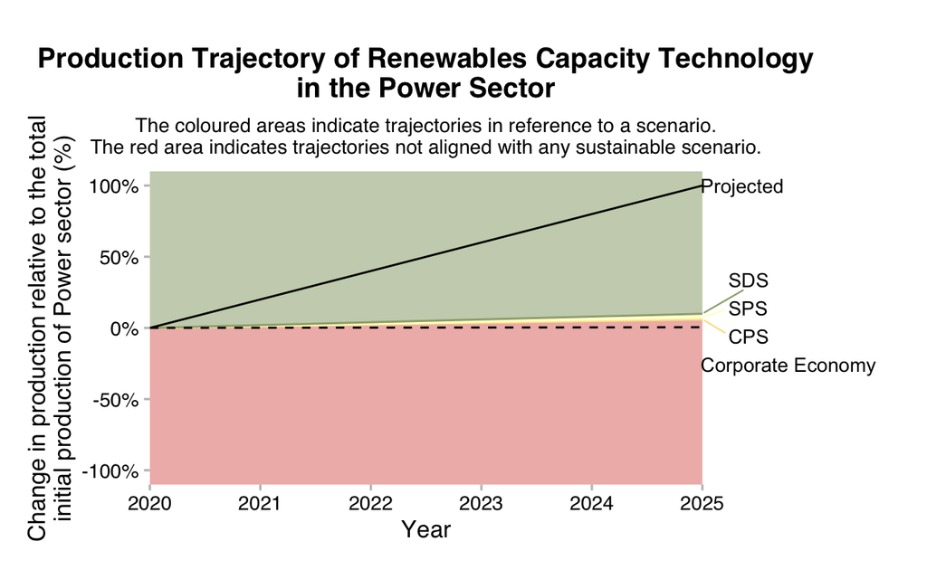

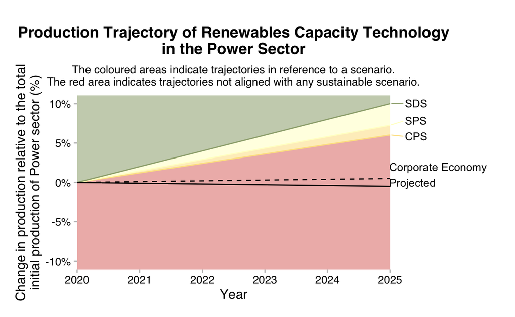

## Problem 2: Increasing Technologies with Zero Initial Production

Another large issue arises when the portfolio initially has no production in an increasing technology. When using the sector market share percentage, we note that a production target may be added for technologies, even if no initial production exists for this technology, so long as there is exposure to the sector.

For example, if a portfolio has only gas production, we would expect targets to be added for renewables. We could reasonably imagine an output dataset that looks like this:

**SMSP Renewables Production (SDS)**

| Sector | Technology | Year | Metric | Production |
| --- | --- | --- | --- | --- |
| power | renewablescap | 2020 | projected | 0 |
| power | renewablescap | 2025 | projected | 100 |
| power | coalcap | 2020 | projected | 100 |
| power | coalcap | 2025 | projected | 50 |
| power | renewablescap | 2020 | target_SDS | 0 |
| power | renewablescap | 2025 | target_SDS | 200 |
| power | coalcap | 2020 | target_SDS | 100 |
| power | coalcap | 2025 | target_SDS | 25 |

With the current plotting method, we would be trying to plot this value:

$\frac{p_i(t)}{p_i(t_0)}$

Consider in particular the renewables targets. Since $p_{renewables}(t_0) = 0MW$, we would be trying to divide by 0. Said otherwise, to build out any amount from an initial value of $0MW$ would require an infinite percent growth.

# Solution: Plot Portfolio-Invariant Units

One possible solution to this problem can be seen if we re-arrange the target calculation functions.

For the technology-market share we can express the target function as:

$$\frac{p_i^{target}(t) -
p_i(t_0)}{p_i(t_0)} = \frac{s_i(t)-s_i(t_0)}{s_i(t_0)}$$

and similarly for the sector-market share:

$$\frac{p_i^{target}(t) -
p_i(t_0)}{P(t_0)} = \frac{s_i(t)-s_i(t_0)}{S(t_0)}$$

In both cases, we have collected all portfolio-related values to the LHS and scenario related values to the RHS. The common units here, then, are Percent Change in either the Technology or Sector.

Let’s see how this might address the problems posed above:

## Problem 1 Solved: Benchmarks for Increasing Technologies

First, let’s calculate the output of our two loanbooks (taken from above) and calculate the values above:

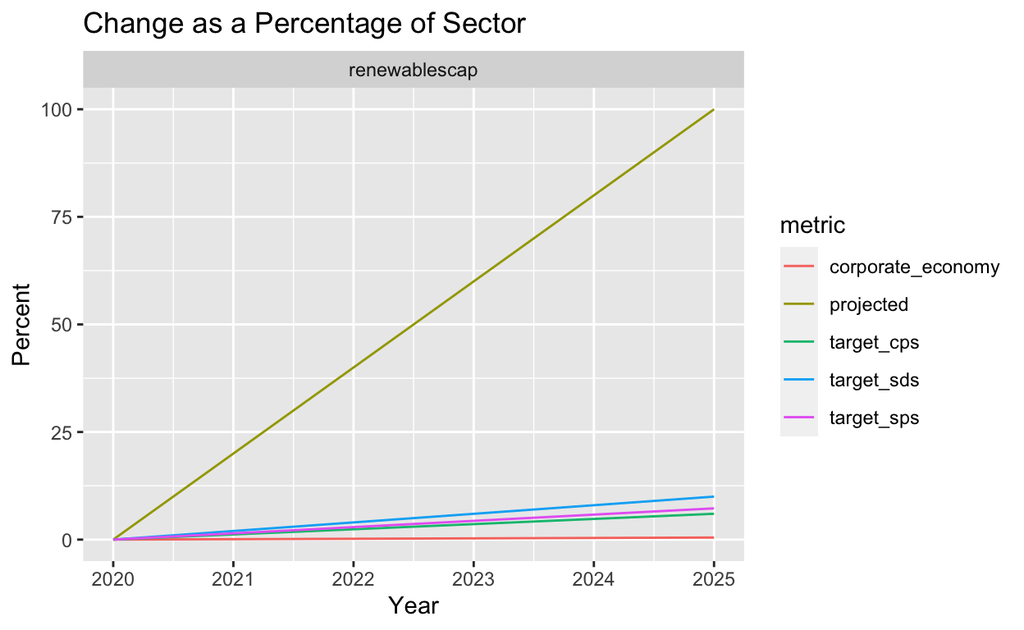

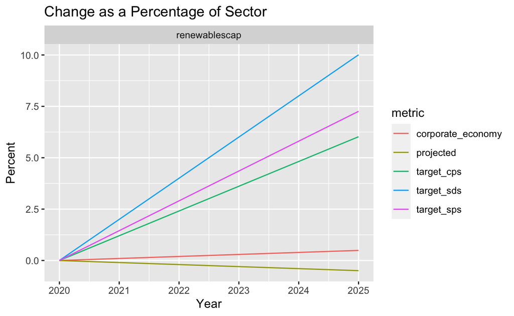

It is a little bit difficult to see what is going on with the benchmark values, since the portfolio values are messing with the scale, so let’s remove them for now:

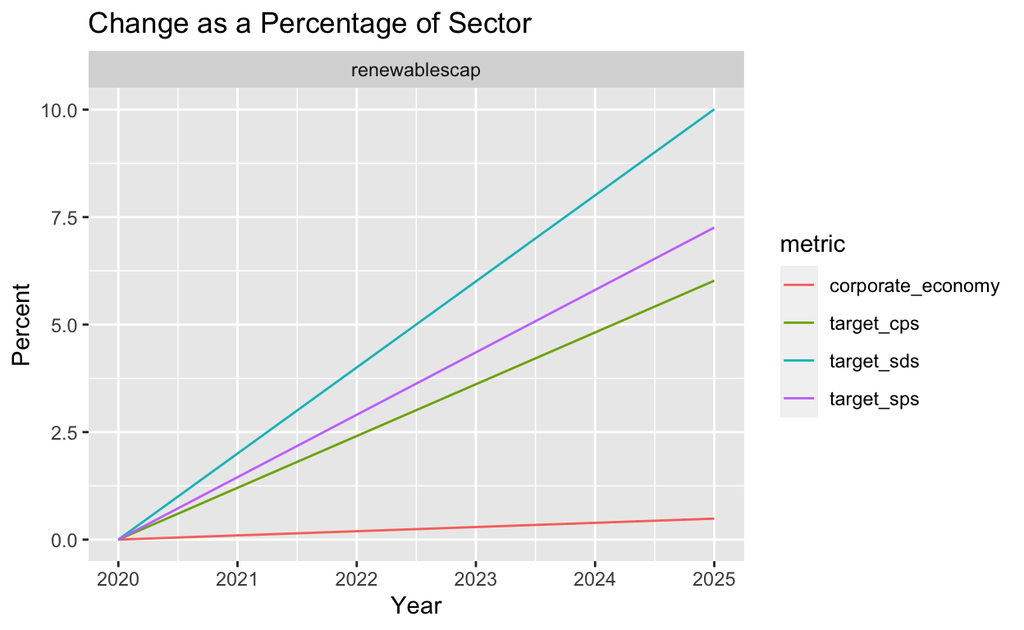

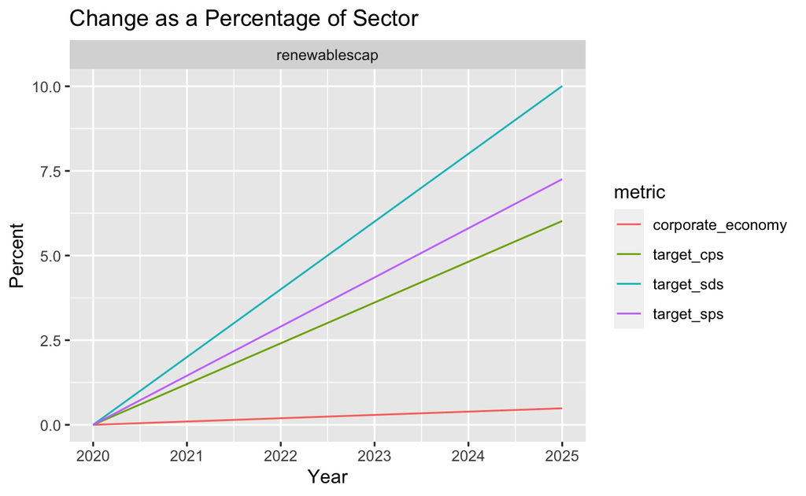

We see that the benchmark now consistently falls in the same trajectory in comparison to the targets, for either portfolio.

## Problem 2 Solved: Increasing Technologies with Zero Initial Production

Similarly, it is straight-forward to show that plotting this value allows us to plot the percent change from a technology that initially starts at $0MW$. The value that we are now plotting is:

$$\frac{p_i(t) -
p_i(t_0)}{P(t_0)}$$

It is completely fine that $p_i(t_0) = 0MW$, so long as there is some initial sectoral production, $P(t_0)$.

For our above example, the plots would look something like this:

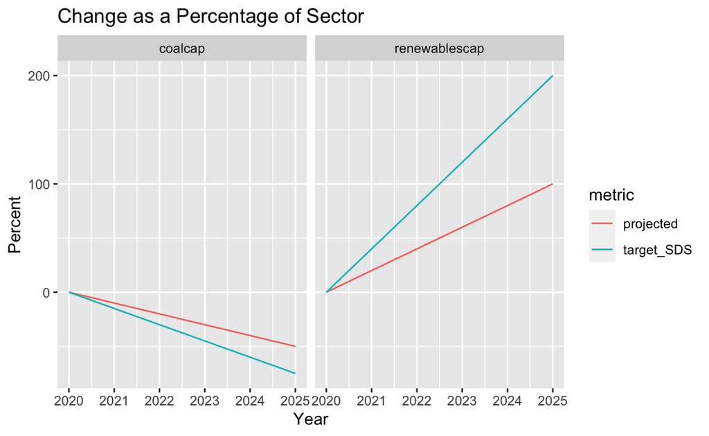